# Coursera - Practical Machine Learning - Course Project

Rafael Encinas

## Overview

This is the report for the Course Project of Practical Machine Learning Class, in Coursera.org. The goal for the project is to predict the manner in which people did some exercises. Using devices such as Jawbone Up, Nike FuelBand, and Fitbit it is now possible to collect a large amount of data about personal activity relatively inexpensively. One thing that people regularly do is quantify how much of a particular activity they do, but they rarely quantify how well they do it.

In this project, we used data from accelerometers on the belt, forearm, arm, and dumbell of 6 participants. They were asked to perform barbell lifts correctly and incorrectly in 5 different ways. The data for this project come from this source: http://groupware.les.inf.puc-rio.br/har.

## Reading and Cleaning Data

In this section, it will be demonstrated the that were used to read data into [R] and clean the variables that will not be used in the prediction model.

First, we need to read data into [R]. The files were downloaded from the links provided by the Course:

- https://d396qusza40orc.cloudfront.net/predmachlearn/pml-training.csv
- https://d396qusza40orc.cloudfront.net/predmachlearn/pml-testing.csv

```r
training <- read.csv("pml-training.csv", header=T, na.strings="NA")
testing <- read.csv("pml-testing.csv", header=T, na.strings="NA")
```

Let’s look some carachteristics of the data:

```r
str(training)
```

```
## 'data.frame':    19622 obs. of  160 variables:
##  $ X                       : int  1 2 3 4 5 6 7 8 9 10 ...
##  $ user_name               : Factor w/ 6 levels "adelmo","carlitos",..: 2 2 2 2 2 2 2 2 2 2 ...
##  $ raw_timestamp_part_1    : int  1323084231 1323084231 1323084231 1323084232 1323084232 1323084232 1323084232 1323084232 1323084232 1323084232 ...
##  $ raw_timestamp_part_2    : int  788290 808298 820366 120339 196328 304277 368296 440390 484323 484434 ...
##  $ cvtd_timestamp          : Factor w/ 20 levels "02/12/2011 13:32",..: 9 9 9 9 9 9 9 9 9 9 ...
##  $ new_window              : Factor w/ 2 levels "no","yes": 1 1 1 1 1 1 1 1 1 1 ...
##  $ num_window              : int  11 11 11 12 12 12 12 12 12 12 ...
##  $ roll_belt               : num  1.41 1.41 1.42 1.48 1.48 1.45 1.42 1.42 1.43 1.45 ...
##  $ pitch_belt              : num  8.07 8.07 8.07 8.05 8.07 8.06 8.09 8.13 8.16 8.17 ...
##  $ yaw_belt                : num  -94.4 -94.4 -94.4 -94.4 -94.4 -94.4 -94.4 -94.4 -94.4 -94.4 ...
##  $ total_accel_belt        : int  3 3 3 3 3 3 3 3 3 3 ...
##  $ kurtosis_roll_belt      : Factor w/ 397 levels "","-0.016850",..: 1 1 1 1 1 1 1 1 1 1 ...
##  $ kurtosis_picth_belt     : Factor w/ 317 levels "","-0.021887",..: 1 1 1 1 1 1 1 1 1 1 ...
##  $ kurtosis_yaw_belt       : Factor w/ 2 levels "","#DIV/0!": 1 1 1 1 1 1 1 1 1 1 ...
```

[output cut: 86 more lines]

```r
head(training[,1:10])
```

```
##   X user_name raw_timestamp_part_1 raw_timestamp_part_2   cvtd_timestamp
## 1 1  carlitos           1323084231               788290 05/12/2011 11:23
## 2 2  carlitos           1323084231               808298 05/12/2011 11:23
## 3 3  carlitos           1323084231               820366 05/12/2011 11:23
## 4 4  carlitos           1323084232               120339 05/12/2011 11:23
## 5 5  carlitos           1323084232               196328 05/12/2011 11:23
## 6 6  carlitos           1323084232               304277 05/12/2011 11:23
##   new_window num_window roll_belt pitch_belt yaw_belt
## 1         no         11      1.41       8.07    -94.4
## 2         no         11      1.41       8.07    -94.4
## 3         no         11      1.42       8.07    -94.4
## 4         no         12      1.48       8.05    -94.4
## 5         no         12      1.48       8.07    -94.4
## 6         no         12      1.45       8.06    -94.4
```

The first seven columns are ID variables, so we decided to exclude them:

```r
training <- training[,-c(1:7)]
testing <- testing[,-c(1:7)]
```

The data contains some variables that have a high number of missing values (NA). Here, we can see that this variables have almost 98% of their rows with NAs

```r
sumNAs <- apply(training,2,function(x) {sum(is.na(x))})
anyNAs <- sumNAs[which(sumNAs > 0)]
anyNAs <- anyNAs / nrow(training)
unique(anyNAs)
```

```
## [1] 0.9793089
```

This variables were excluded for the analysis:

```r
training <- training[which(sumNAs == 0)]
testing <- testing[which(sumNAs == 0)]
```

There were 67 variables that were excluded:

```r
anyNAs
```

```
##            max_roll_belt           max_picth_belt            min_roll_belt
##                0.9793089                0.9793089                0.9793089
##           min_pitch_belt      amplitude_roll_belt     amplitude_pitch_belt
##                0.9793089                0.9793089                0.9793089
##     var_total_accel_belt            avg_roll_belt         stddev_roll_belt
##                0.9793089                0.9793089                0.9793089
##            var_roll_belt           avg_pitch_belt        stddev_pitch_belt
##                0.9793089                0.9793089                0.9793089
##           var_pitch_belt             avg_yaw_belt          stddev_yaw_belt
##                0.9793089                0.9793089                0.9793089
##             var_yaw_belt            var_accel_arm             avg_roll_arm
##                0.9793089                0.9793089                0.9793089
##          stddev_roll_arm             var_roll_arm            avg_pitch_arm
##                0.9793089                0.9793089                0.9793089
##         stddev_pitch_arm            var_pitch_arm              avg_yaw_arm
##                0.9793089                0.9793089                0.9793089
##           stddev_yaw_arm              var_yaw_arm             max_roll_arm
##                0.9793089                0.9793089                0.9793089
##            max_picth_arm              max_yaw_arm             min_roll_arm
##                0.9793089                0.9793089                0.9793089
##            min_pitch_arm              min_yaw_arm       amplitude_roll_arm
##                0.9793089                0.9793089                0.9793089
##      amplitude_pitch_arm        amplitude_yaw_arm        max_roll_dumbbell
##                0.9793089                0.9793089                0.9793089
##       max_picth_dumbbell        min_roll_dumbbell       min_pitch_dumbbell
##                0.9793089                0.9793089                0.9793089
##  amplitude_roll_dumbbell amplitude_pitch_dumbbell       var_accel_dumbbell
##                0.9793089                0.9793089                0.9793089
##        avg_roll_dumbbell     stddev_roll_dumbbell        var_roll_dumbbell
##                0.9793089                0.9793089                0.9793089
##       avg_pitch_dumbbell    stddev_pitch_dumbbell       var_pitch_dumbbell
##                0.9793089                0.9793089                0.9793089
##         avg_yaw_dumbbell      stddev_yaw_dumbbell         var_yaw_dumbbell
##                0.9793089                0.9793089                0.9793089
##         max_roll_forearm        max_picth_forearm         min_roll_forearm
##                0.9793089                0.9793089                0.9793089
##        min_pitch_forearm   amplitude_roll_forearm  amplitude_pitch_forearm
##                0.9793089                0.9793089                0.9793089
##        var_accel_forearm         avg_roll_forearm      stddev_roll_forearm
##                0.9793089                0.9793089                0.9793089
##         var_roll_forearm        avg_pitch_forearm     stddev_pitch_forearm
##                0.9793089                0.9793089                0.9793089
##        var_pitch_forearm          avg_yaw_forearm       stddev_yaw_forearm
##                0.9793089                0.9793089                0.9793089
##          var_yaw_forearm
##                0.9793089
```

Other variables that are not usefull for the model are the ones tha have near zero variance.

```r
library(caret)
nsv <- nearZeroVar(training,saveMetrics=TRUE)
nsv$seq <- seq(1:nrow(nsv))
nonzerovar <- nsv[which(nsv$nzv == FALSE),5]
training <- training[nonzerovar]
testing <- testing[nonzerovar]
```

33 variables were excluded:

```r
rownames(nsv[which(nsv$nzv == TRUE),])
```

```
##  [1] "kurtosis_roll_belt"      "kurtosis_picth_belt"
##  [3] "kurtosis_yaw_belt"       "skewness_roll_belt"
##  [5] "skewness_roll_belt.1"    "skewness_yaw_belt"
##  [7] "max_yaw_belt"            "min_yaw_belt"
##  [9] "amplitude_yaw_belt"      "kurtosis_roll_arm"
## [11] "kurtosis_picth_arm"      "kurtosis_yaw_arm"
## [13] "skewness_roll_arm"       "skewness_pitch_arm"
## [15] "skewness_yaw_arm"        "kurtosis_roll_dumbbell"
## [17] "kurtosis_picth_dumbbell" "kurtosis_yaw_dumbbell"
## [19] "skewness_roll_dumbbell"  "skewness_pitch_dumbbell"
## [21] "skewness_yaw_dumbbell"   "max_yaw_dumbbell"
## [23] "min_yaw_dumbbell"        "amplitude_yaw_dumbbell"
## [25] "kurtosis_roll_forearm"   "kurtosis_picth_forearm"
## [27] "kurtosis_yaw_forearm"    "skewness_roll_forearm"
## [29] "skewness_pitch_forearm"  "skewness_yaw_forearm"
## [31] "max_yaw_forearm"         "min_yaw_forearm"
## [33] "amplitude_yaw_forearm"
```

Let’s look at some variables:

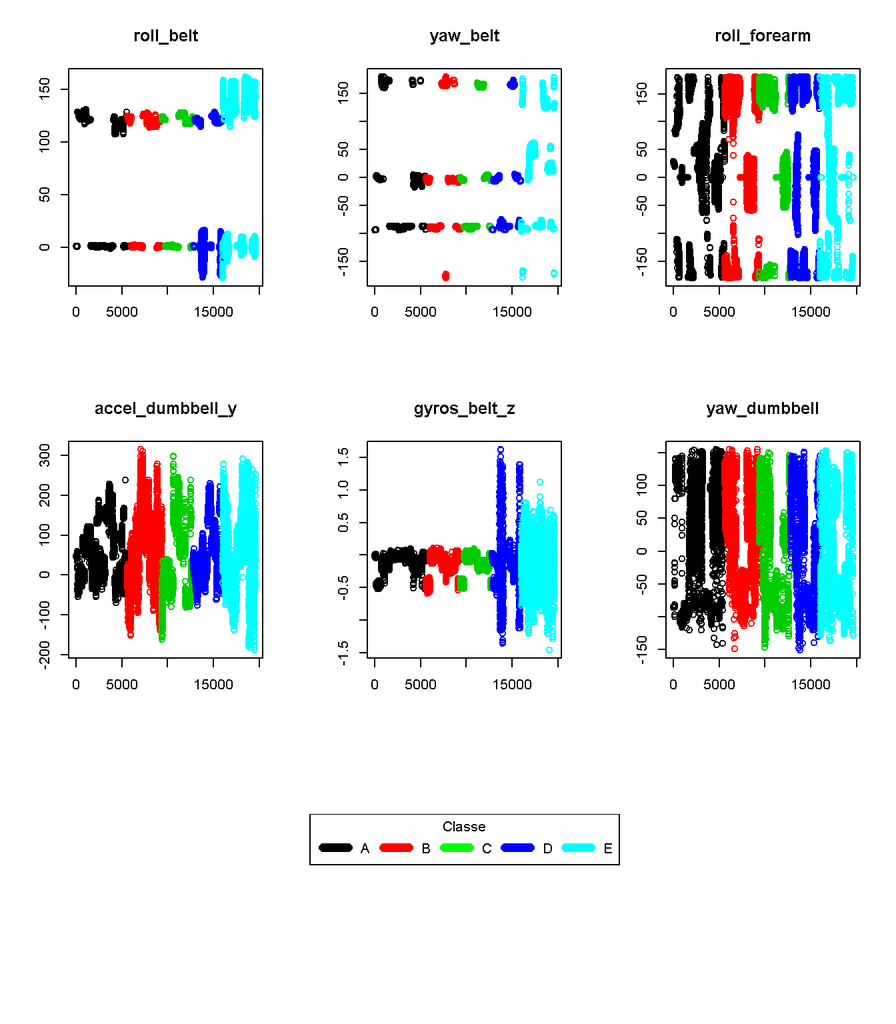

```r
m <- matrix(c(1,2,3,4,5,6,7,7,7),nrow = 3,ncol = 3,byrow = TRUE)
layout(mat = m,heights = c(0.4,0.4,0.3))
par(oma=c(0,0,0,0))
plot(training$roll_belt, col=training$classe, main="roll_belt", xlab="", ylab="")
plot(training$yaw_belt, col=training$classe, main="yaw_belt", xlab="", ylab="")
plot(training$roll_forearm, col=training$classe, main="roll_forearm", xlab="", ylab="")
plot(training$accel_dumbbell_y, col=training$classe, main="accel_dumbbell_y", xlab="", ylab="")
plot(training$gyros_belt_z, col=training$classe, main="gyros_belt_z", xlab="", ylab="")
plot(training$yaw_dumbbell, col=training$classe, main="yaw_dumbbell", xlab="", ylab="")
plot(1, type = "n", axes=FALSE, xlab="", ylab="")
legend(x = "top",inset = 0,c("A", "B", "C", "D", "E"), lty=1, lwd=6.5, col=c("black", "red", "green", "blue", "cyan"), horiz=TRUE, title = "Classe")
```

## Prediction Model

The data provided by the course consists in two files: training and testing. But the testing file has only 20 observations. So we decided to create a testing data inside the training data. Cross validation occurs when we estimate the test set accuracy with the training set. First, we need to split the training set into training and testing sets. Second, we build a model on the new training set. third, we evaluate on the test set.

Below is the split of the traing set into trainData and testData:

```r
set.seed(12345)
inTrain <- createDataPartition(y=training$classe, p=0.6, list=F)
trainData <- training[inTrain,]
testData <- training[-inTrain,]
```

Now, we can build the prediction model in the trainingData. The method chosen for the prediction was “random forests”.

```r
train_control <- trainControl(method="boot", number=10, allowParallel=TRUE)
modFit <- train(classe ~ .,method="rf", data=trainData, trControl=train_control, ntree=250)
modFit
```

```
## Random Forest
##
## 11776 samples
##    52 predictor
##     5 classes: 'A', 'B', 'C', 'D', 'E'
##
## No pre-processing
## Resampling: Bootstrapped (10 reps)
##
## Summary of sample sizes: 11776, 11776, 11776, 11776, 11776, 11776, ...
##
## Resampling results across tuning parameters:
##
##   mtry  Accuracy   Kappa      Accuracy SD  Kappa SD
##    2    0.9859450  0.9822111  0.001915314  0.002417298
##   27    0.9858245  0.9820571  0.001899026  0.002405799
##   52    0.9796736  0.9742709  0.002558253  0.003248631
##
## Accuracy was used to select the optimal model using  the largest value.
## The final value used for the model was mtry = 2.
```

Than, we can see the accuracy of the model in the testData:

```r
pred <- predict(modFit,testData)
confusionMatrix(pred, testData$classe)
```

```
## Confusion Matrix and Statistics
##
##           Reference
## Prediction    A    B    C    D    E
##          A 2228    7    0    0    0
##          B    4 1507    8    0    0
##          C    0    4 1359   22    2
##          D    0    0    1 1260    3
##          E    0    0    0    4 1437
##
## Overall Statistics
##
##                Accuracy : 0.993
##                  95% CI : (0.9909, 0.9947)
##     No Information Rate : 0.2845
##     P-Value [Acc > NIR] : < 2.2e-16
##
##                   Kappa : 0.9911
##  Mcnemar's Test P-Value : NA
##
## Statistics by Class:
##
##                      Class: A Class: B Class: C Class: D Class: E
## Sensitivity            0.9982   0.9928   0.9934   0.9798   0.9965
## Specificity            0.9988   0.9981   0.9957   0.9994   0.9994
## Pos Pred Value         0.9969   0.9921   0.9798   0.9968   0.9972
## Neg Pred Value         0.9993   0.9983   0.9986   0.9960   0.9992
## Prevalence             0.2845   0.1935   0.1744   0.1639   0.1838
## Detection Rate         0.2840   0.1921   0.1732   0.1606   0.1832
## Detection Prevalence   0.2849   0.1936   0.1768   0.1611   0.1837
## Balanced Accuracy      0.9985   0.9954   0.9945   0.9896   0.9980
```

The “out of sample error” is the error rate that we get on a new dataset, called sometimes “generaliztion error”. Above, we can see that the accuracy of the model in the testData is 99,3%, so we estimate that the out of sample error should be 0,7%.

With the function “varImp()” we can see the importance of each variable in the model:

```r
varImp(modFit)
```

```
## rf variable importance
##
##   only 20 most important variables shown (out of 52)
##
##                   Overall
## roll_belt          100.00
## yaw_belt            81.41
## magnet_dumbbell_z   78.44
## pitch_belt          67.10
## magnet_dumbbell_y   66.22
## pitch_forearm       65.27
## roll_forearm        52.52
## magnet_dumbbell_x   51.76
## magnet_belt_y       48.78
## accel_belt_z        48.36
## magnet_belt_z       46.71
## accel_dumbbell_y    45.08
## roll_dumbbell       44.46
## roll_arm            41.33
## accel_dumbbell_z    39.39
## gyros_belt_z        34.98
## accel_forearm_x     34.65
## yaw_dumbbell        33.16
## gyros_dumbbell_y    31.56
## accel_dumbbell_x    31.46
```

## Apply prediction model to test data

The second part of the assignment consists in apllying the prediction model to a test data, which has 20 test cases.

```r
pred2 <- predict(modFit,testing)
```

All predictions submitted to Coursera were correct.